# Rumour Veracity and Support

Import the required libraries

```python
!pip install tensorflow_text
```

```
     |████████████████████████████████| 4.4 MB 2.7 MB/s
```

```python
import tensorflow as tf
import tensorflow_hub as hub
import tensorflow_text as text
AUTOTUNE = tf.data.experimental.AUTOTUNE
import numpy as np
import pandas as pd

import tensorflow_datasets as tfds
import pathlib
import shutil
import tempfile
import seaborn as sns
from  IPython import display
from matplotlib import pyplot as plt
```

```python
# A dependency of the preprocessing for BERT inputs
!pip install -q -U tensorflow-text

!pip install -q tf-models-official

import os
import tensorflow_hub as hub
import tensorflow_text as text
from official.nlp import optimization  # to create AdamW optimizer
tf.get_logger().setLevel('ERROR')
```

[output not shown]

```python
logdir = pathlib.Path(tempfile.mkdtemp())/"tensorboard_logs"
shutil.rmtree(logdir, ignore_errors=True)

# Load the TensorBoard notebook extension
%load_ext tensorboard

# Open an embedded TensorBoard viewer
%tensorboard --logdir {logdir}/models
```

# Plotting function

```python
from itertools import cycle
def plotter(history_hold, metric = 'binary_crossentropy', ylim=[0.0, 1.0]):
  cycol = cycle('bgrcmk')
  for name, item in history_hold.items():
    y_train = item.history[metric]
    y_val = item.history['val_' + metric]
    x_train = np.arange(0,len(y_val))

    c=next(cycol)

    plt.plot(x_train, y_train, c+'-', label=name+'_train')
    plt.plot(x_train, y_val, c+'--', label=name+'_val')

  plt.legend()
  plt.xlim([1, max(plt.xlim())])
  plt.ylim(ylim)
  plt.xlabel('Epoch')
  plt.ylabel(metric)
  plt.grid(True)
```

**mount the google drive**

```python
# mount the drive
from google.colab import drive
drive.mount('/content/drive')
```

```python
!cp /content/drive/'My Drive'/Rumour_data.zip .
!unzip -q -o Rumour_data.zip
!rm Rumour_data.zip
```

# Import the dataset

```python
import pandas as pd
df =  pd.read_csv('/content/Rumour_data/twitter_dataset.csv')
```

```python
df.head(5)
```

|  | Type | Msg_ID | Source_Msg_ID | Text | Topic | Class |
| --- | --- | --- | --- | --- | --- | --- |
| 0 | Source | 5.810630e+17 | -1.000000e+00 | #4U9525: Robin names Andreas Lubitz as the cop... | germanwings-crash | -1 |
| 1 | Reply | 5.810700e+17 | 5.810630e+17 | @thatjohn Have they named the pilot? | germanwings-crash | query |
| 2 | Reply | 5.810640e+17 | 5.810630e+17 | @thatjohn @mschenk | germanwings-crash | comment |
| 3 | Source | 5.813860e+17 | -1.000000e+00 | RT @khjelmgaard: German media reporting #Andre... | germanwings-crash | -1 |
| 4 | Reply | 5.815760e+17 | 5.813860e+17 | @tinkalee_12 @USATODAY @khjelmgaard #F4Phantom... | germanwings-crash | comment |

Data Exploration

```python
# check to make sure the dtype of attributes is correct
df.dtypes
```

```
Type              object
Msg_ID           float64
Source_Msg_ID    float64
Text              object
Topic             object
Class             object
dtype: object
```

```python
# the Source_msg_id is related to the source tweet
df.Source_Msg_ID.value_counts()
```

```
-1.000000e+00    381
 7.581600e+17    154
 5.002790e+17    105
 5.443300e+17    102
 9.348290e+17     98
                ...
 5.803600e+17      2
 5.768130e+17      2
 5.534670e+17      2
 5.445140e+17      2
 5.534770e+17      1
Name: Source_Msg_ID, Length: 321, dtype: int64
```

```python
# the Msg_id is related to one particular news based on #sydneySeige
df.Msg_ID.value_counts()
```

```
5.535880e+17    34
5.535870e+17    34
5.249260e+17    31
5.528120e+17    24
5.442930e+17    24
                ..
9.021590e+17     1
4.993730e+17     1
7.677650e+17     1
5.007150e+17     1
5.535240e+17     1
Name: Msg_ID, Length: 2510, dtype: int64
```

```python
# check the unique types of Type attribute
df.Type.unique()
```

```
array(['Source', 'Reply'], dtype=object)
```

```python
# source is defined by -1
# replies are defined by the corresponding values
df.Class.unique()
```

```
array(['-1', 'query', 'comment', 'deny', 'support'], dtype=object)
```

```python
# check the number of topics
df.Topic.unique()
```

```
array(['germanwings-crash', 'prince-toronto', 'putinmissing', 'illary',
       'ottawashooting', 'ebola-essien', 'ferguson', 'sydneysiege',
       'charliehebdo', 'virgin-weapons', 'cnn-lies', 'clinton-florida',
       'pence-sacrifice', 'immigrants-wildfires', 'mississippi-dry',
       'obama-harvey', 'nat-geo-footage', 'inflatable-dam',
       'blm-hurricane', 'osteen-yacht', 'irma-cat-6', 'red-cross',
       'wildfires-deduction', 'lightning-river', 'fukushima-dump',
       'afghanistan', 'cape-tornadoes', 'clinton-ads', 'shark-hurricane',
       'texas-mosque', 'fukushima-falling', 'barbara-bush',
       'lawn-tornado', 'harvey-donations', 'african-american', 'ark-park',
       'fire-ants'], dtype=object)
```

Analysis :The source tweet contains the main information and based on that the reply tweets can be categorised. So we can use each source tweet and a reply tweet as a pair and use a seperator like '|' between the source tweet and the reply tweet. This '|' will be encoded with a particular value by the bert model.

# Create a pair of each reply tweet and source tweet

```python
# the below Msg_id corresponds to the Source_msg displayed below
df[df['Msg_ID']==5.810630e+17]
```

|  | Type | Msg_ID | Source_Msg_ID | Text | Topic | Class |
| --- | --- | --- | --- | --- | --- | --- |
| 0 | Source | 5.810630e+17 | -1.0 | #4U9525: Robin names Andreas Lubitz as the cop... | germanwings-crash | -1 |

```python
# each reply tweet correponds to each source tweet by the 'Source_Msg_ID'
# so the 2 reply tweets displayed below correspond to the source tweet with (Msg_id = v5.810630e+17 )
df[df['Source_Msg_ID']==5.810630e+17]
```

|  | Type | Msg_ID | Source_Msg_ID | Text | Topic | Class |
| --- | --- | --- | --- | --- | --- | --- |
| 1 | Reply | 5.810700e+17 | 5.810630e+17 | @thatjohn Have they named the pilot? | germanwings-crash | query |
| 2 | Reply | 5.810640e+17 | 5.810630e+17 | @thatjohn @mschenk | germanwings-crash | comment |

```python
# seperate the source records in a new dataframe
df_source = df[df['Type']=='Source']

# create a dictionary of msg_id as the key and the source tweet text as the value
source_dict = {}

# dictionary key = Msg_id and the value will be tweet text
for i in range(df_source.shape[0]):

  source_dict[df_source.iloc[i, df_source.columns.get_loc("Msg_ID")]] = df_source.iloc[i, df_source.columns.get_loc("Text")]
```

```python
# all the source_tweet text can be accessed using the msg_id(key)
source_dict.get(5.810630e+17)
```

```
'#4U9525: Robin names Andreas Lubitz as the copilot in the flight deck who crashed the aircraft.'
```

```python
# exclude all the rows with source msg
df_exclude_source = df[df['Class']!='-1']

for i in range(df_exclude_source.shape[0]):
  msg_id = df_exclude_source.iloc[i, df_exclude_source.columns.get_loc("Source_Msg_ID")]

  # access the source text using the msg id from the source dictionary
  pair_tweet = source_dict.get(msg_id) + ' | ' + df_exclude_source.iloc[i, df_exclude_source.columns.get_loc("Text")]

  # conactenate the source tweet and reply using | as a seperator

  df_exclude_source.iloc[i, df_exclude_source.columns.get_loc("Text")] = pair_tweet
```

```python
# the tweet text will contain source tweet | reply tweet
df_exclude_source.head(5)
```

|  | Type | Msg_ID | Source_Msg_ID | Text | Topic | Class |
| --- | --- | --- | --- | --- | --- | --- |
| 1 | Reply | 5.810700e+17 | 5.810630e+17 | #4U9525: Robin names Andreas Lubitz as the cop... | germanwings-crash | query |
| 2 | Reply | 5.810640e+17 | 5.810630e+17 | #4U9525: Robin names Andreas Lubitz as the cop... | germanwings-crash | comment |
| 4 | Reply | 5.815760e+17 | 5.813860e+17 | RT @khjelmgaard: German media reporting #Andre... | germanwings-crash | comment |
| 5 | Reply | 5.820480e+17 | 5.813860e+17 | RT @khjelmgaard: German media reporting #Andre... | germanwings-crash | comment |
| 6 | Reply | 5.822060e+17 | 5.813860e+17 | RT @khjelmgaard: German media reporting #Andre... | germanwings-crash | comment |

```python
# a pair consisting of source tweet and reply tweet seperated by '|' is created
df_exclude_source['Text'].iloc[0]
```

```
'#4U9525: Robin names Andreas Lubitz as the copilot in the flight deck who crashed the aircraft. | @thatjohn Have they named the pilot?'
```

Visulaise the Target variable Class

```python
df_exclude_source.Class.unique()
```

```
array(['query', 'comment', 'deny', 'support'], dtype=object)
```

```python
df_exclude_source.Class.value_counts()
```

```
comment    4445
support     792
query       520
deny        496
Name: Class, dtype: int64
```

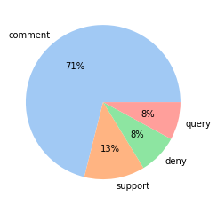

```python
labels = ['comment','support','deny','query']
data = df_exclude_source.Class.value_counts()

colors = sns.color_palette('pastel')[0:5]

#create pie chart
plt.pie(data, labels = labels, colors = colors, autopct='%.0f%%')
plt.show()
```

Analysis: From the above visualization we can conclude that the dataset is imbalanced.

- The comment class has more records than compared to other target class
- Comment class does not contribute much in analysing wether the tweet is a rumour or not
- Also to deal with the imbalance in data we can first train the model to classify comment and not-comment and then classify the remaining records as SDQ(Support, Deny, Query)

Text preprocessing (text cleaning)

```python
import string
import nltk
nltk.download('punkt')
from nltk.tokenize import word_tokenize
from nltk.corpus import stopwords
```

```python
df_exclude_source.head(5)
```

|  | Type | Msg_ID | Source_Msg_ID | Text | Topic | Class |
| --- | --- | --- | --- | --- | --- | --- |
| 1 | Reply | 5.810700e+17 | 5.810630e+17 | #4U9525: Robin names Andreas Lubitz as the cop... | germanwings-crash | query |
| 2 | Reply | 5.810640e+17 | 5.810630e+17 | #4U9525: Robin names Andreas Lubitz as the cop... | germanwings-crash | comment |
| 4 | Reply | 5.815760e+17 | 5.813860e+17 | RT @khjelmgaard: German media reporting #Andre... | germanwings-crash | comment |
| 5 | Reply | 5.820480e+17 | 5.813860e+17 | RT @khjelmgaard: German media reporting #Andre... | germanwings-crash | comment |
| 6 | Reply | 5.822060e+17 | 5.813860e+17 | RT @khjelmgaard: German media reporting #Andre... | germanwings-crash | comment |

```python
# select the Text and Class(Target) attributes and add it to a new dataset
df_preprocess = df_exclude_source[['Text', 'Class']]
df_preprocess.head(5)
```

|  | Text | Class |
| --- | --- | --- |
| 1 | #4U9525: Robin names Andreas Lubitz as the cop... | query |
| 2 | #4U9525: Robin names Andreas Lubitz as the cop... | comment |
| 4 | RT @khjelmgaard: German media reporting #Andre... | comment |
| 5 | RT @khjelmgaard: German media reporting #Andre... | comment |
| 6 | RT @khjelmgaard: German media reporting #Andre... | comment |

The following pre-processing will be applied on the data:

- convert all the text to lower case
- Remove all the punctuations
- Strip the white spaces
- Remove the alphanumeric characters

The '|' seperator between the source tweet and the reply tweet will be retained

```python
# Preprocess the text

import re

# regular expression to remove url
url = r"(https?:\/\/(?:www\.|(?!www))[a-zA-Z0-9][a-zA-Z0-9-]+[a-zA-Z0-9]\.[^\s]{2,}|www\.[a-zA-Z0-9][a-zA-Z0-9-]+[a-zA-Z0-9]\.[^\s]{2,}|https?:\/\/(?:www\.|(?!www))[a-zA-Z0-9]+\.[^\s]{2,}|www\.[a-zA-Z0-9]+\.[^\s]{2,})"

for i in range(df_preprocess.shape[0]):
  # remove url
  preprocess_text = re.sub(url, "", df_preprocess['Text'].iloc[i])
  # remove @ and followed by the word
  preprocess_text = re.sub(r"@\w+", "", preprocess_text)
  df_preprocess['Text'].iloc[i] = preprocess_text


# convert all the text to lower case
df_preprocess["Text"] = df_preprocess["Text"].str.lower()
df_preprocess['Class'] =  df_preprocess['Class'].str.lower()

# remove all punctuations except |
df_preprocess["Text"] = df_preprocess['Text'].str.replace(r'[^\w\s|]', '')


# strip whitespaces
df_preprocess['Text'] = df_preprocess['Text'].str.strip()
df_preprocess['Class'] = df_preprocess['Class'].str.strip()

# remove all alphanumeric characters
df_preprocess['Text']= df_preprocess['Text'].str.replace('[^a-zA-Z|\s]', '')
```

```python
# check to make sure the data pre-processing is applied
df_preprocess.head(5)
```

|  | Text | Class |
| --- | --- | --- |
| 1 | u robin names andreas lubitz as the copilot in... | query |
| 2 | u robin names andreas lubitz as the copilot in... | comment |
| 4 | rt german media reporting andreaslubitz had a... | comment |
| 5 | rt german media reporting andreaslubitz had a... | comment |
| 6 | rt german media reporting andreaslubitz had a... | comment |

```python
# check to make sure the seperator '|' is present between the source and the reply tweet
df_preprocess['Text'].iloc[0]
```

```
'u robin names andreas lubitz as the copilot in the flight deck who crashed the aircraft |  have they named the pilot'
```

To deal with the class imbalance, first we will train the model on the comment Class. So the target Variable will be encoded as comment = 1, non-comment = 0

```python
# preprocessed dataframe for classifying the sdq
df_sdq_data = df_preprocess.copy()

# preprocessed dataframe for classifying the comment and non-comment
df_comment = df_preprocess.copy()
```

```python
# encode comment = 1 and non-comment(support, query, deny) = 0
encode = {
    "comment" : 1,
    "query"  : 0,
    "support" : 0,
    "deny" : 0,
    }

df_comment["Class"] = df_comment["Class"].apply(lambda x: encode[x])
df_comment.head(5)
```

|  | Text | Class |
| --- | --- | --- |
| 1 | u robin names andreas lubitz as the copilot in... | 0 |
| 2 | u robin names andreas lubitz as the copilot in... | 1 |
| 4 | rt german media reporting andreaslubitz had a... | 1 |
| 5 | rt german media reporting andreaslubitz had a... | 1 |
| 6 | rt german media reporting andreaslubitz had a... | 1 |

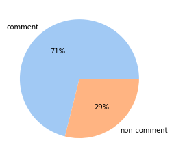

```python
labels = ['comment','non-comment']
data = df_comment.Class.value_counts()

colors = sns.color_palette('pastel')[0:2]

#create pie chart
plt.pie(data, labels = labels, colors = colors, autopct='%.0f%%')
plt.show()
```

Analysis: Still the comment class has more records than compared to the non-comment class. So even if the model predicts each and every class as comment the accuracy will be good. So to avoid this issue I will oversample the train data for the minority class.

# Split the dataset into train , test and validation

```python
df.head(5)
```

|  | Type | Msg_ID | Source_Msg_ID | Text | Topic | Class |
| --- | --- | --- | --- | --- | --- | --- |
| 0 | Source | 5.810630e+17 | -1.000000e+00 | #4U9525: Robin names Andreas Lubitz as the cop... | germanwings-crash | -1 |
| 1 | Reply | 5.810700e+17 | 5.810630e+17 | @thatjohn Have they named the pilot? | germanwings-crash | query |
| 2 | Reply | 5.810640e+17 | 5.810630e+17 | @thatjohn @mschenk | germanwings-crash | comment |
| 3 | Source | 5.813860e+17 | -1.000000e+00 | RT @khjelmgaard: German media reporting #Andre... | germanwings-crash | -1 |
| 4 | Reply | 5.815760e+17 | 5.813860e+17 | @tinkalee_12 @USATODAY @khjelmgaard #F4Phantom... | germanwings-crash | comment |

```python
# split the dataset into train,validation and test set
from sklearn.model_selection import train_test_split

# split the dataset into train dataset(60%) and remainder dataset(40%)
X_train, X_rem, y_train, y_rem = train_test_split(df_comment['Text'], df_comment['Class'],train_size=0.6, shuffle=True,stratify=df_comment['Class'], random_state=1)

# split the remaining 40% data between validation and test set
x_val, x_test, y_val, y_test = train_test_split(X_rem, y_rem ,test_size=0.5, shuffle=True, random_state=1)
```

```python
print('shape of train data :',X_train.shape[0])
print('shape of validation data :',x_val.shape[0])
print('shape of test data :',x_test.shape[0])
```

```
shape of train data : 3751
shape of validation data : 1251
shape of test data : 1251
```

# Oversample the train data to deal with the class imbalance

```python
# conatenate the training data (X_train and y_train to oversample the minority class)

df_concat = { 'tweet': X_train, 'Class': y_train }

df_concat = pd.DataFrame(df_concat)

df_concat.head(5)
```

|  | tweet | Class |
| --- | --- | --- |
| 3474 | this is shot that captures the sydneysiege she... | 0 |
| 2091 | every hours a black male is killed in the uni... | 0 |
| 2349 | ferguson pd charged henrydavis w destruction o... | 1 |
| 1135 | snipers set up on national art gallery as we r... | 1 |
| 1403 | more shots fired just off parliament hill poli... | 1 |

```python
from sklearn.utils import resample
# Seperate the majority and the minority class
#df_concat = df_comment.copy()
df_majority = df_concat[df_concat.Class == 1]
df_minority = df_concat[df_concat.Class == 0]

# upsample the minority class to increase the number of samples for Class = 0 (non-comment)
df_minority_upsampled = resample(df_minority, replace=True, n_samples = 2600, random_state = 1)

# Combine the majority class(CLass = 1) with the upsampled minority class(Class = 0)
df_oversampled = pd.concat([df_majority, df_minority_upsampled])

# check the value counts to make sure the minority class is upsampled
df_oversampled.Class.value_counts()

# Conclusion : So the data is oversampled with 2600 samples for the minority class(Class = 0)
```

```
1    2666
0    2600
Name: Class, dtype: int64
```

```python
# create a numpy array with the attribute tweet as Features
X_train = df_oversampled['tweet'].values

# store the target variable in t_train
y_train = df_oversampled['Class'].values

# all the above are converted to numpy array for further processing
```

```python
print('shape of train data :',X_train.shape[0])
print('shape of validation data :',x_val.shape[0])
print('shape of test data :',x_test.shape[0])
```

```
shape of train data : 5266
shape of validation data : 1251
shape of test data : 1251
```

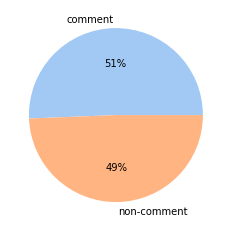

```python
labels = ['comment','non-comment']
data = df_oversampled.Class.value_counts()

colors = sns.color_palette('pastel')[0:2]

#create pie chart
plt.pie(data, labels = labels, colors = colors, autopct='%.0f%%')
plt.show()
```

Analysis : From the above pie chart we can conclude that there is equal number of records for for comment and non-comment class, so the imbalanced data problem is resolved.

select the specific bert model

```python
bert_model_name = 'electra_base'

map_name_to_handle = {
    'bert_en_uncased_L-12_H-768_A-12':
        'https://tfhub.dev/tensorflow/bert_en_uncased_L-12_H-768_A-12/3',
    'bert_en_cased_L-12_H-768_A-12':
        'https://tfhub.dev/tensorflow/bert_en_cased_L-12_H-768_A-12/3',
    'bert_multi_cased_L-12_H-768_A-12':
        'https://tfhub.dev/tensorflow/bert_multi_cased_L-12_H-768_A-12/3',
    'small_bert/bert_en_uncased_L-2_H-128_A-2':
        'https://tfhub.dev/tensorflow/small_bert/bert_en_uncased_L-2_H-128_A-2/1',
    'small_bert/bert_en_uncased_L-2_H-256_A-4':
        'https://tfhub.dev/tensorflow/small_bert/bert_en_uncased_L-2_H-256_A-4/1',
    'small_bert/bert_en_uncased_L-2_H-512_A-8':
        'https://tfhub.dev/tensorflow/small_bert/bert_en_uncased_L-2_H-512_A-8/1',
    'small_bert/bert_en_uncased_L-2_H-768_A-12':
        'https://tfhub.dev/tensorflow/small_bert/bert_en_uncased_L-2_H-768_A-12/1',
    'small_bert/bert_en_uncased_L-4_H-128_A-2':
        'https://tfhub.dev/tensorflow/small_bert/bert_en_uncased_L-4_H-128_A-2/1',
    'small_bert/bert_en_uncased_L-4_H-256_A-4':
        'https://tfhub.dev/tensorflow/small_bert/bert_en_uncased_L-4_H-256_A-4/1',
    'small_bert/bert_en_uncased_L-4_H-512_A-8':
        'https://tfhub.dev/tensorflow/small_bert/bert_en_uncased_L-4_H-512_A-8/1',
    'small_bert/bert_en_uncased_L-4_H-768_A-12':
        'https://tfhub.dev/tensorflow/small_bert/bert_en_uncased_L-4_H-768_A-12/1',
    'small_bert/bert_en_uncased_L-6_H-128_A-2':
        'https://tfhub.dev/tensorflow/small_bert/bert_en_uncased_L-6_H-128_A-2/1',
    'small_bert/bert_en_uncased_L-6_H-256_A-4':
        'https://tfhub.dev/tensorflow/small_bert/bert_en_uncased_L-6_H-256_A-4/1',
    'small_bert/bert_en_uncased_L-6_H-512_A-8':
        'https://tfhub.dev/tensorflow/small_bert/bert_en_uncased_L-6_H-512_A-8/1',
    'small_bert/bert_en_uncased_L-6_H-768_A-12':
        'https://tfhub.dev/tensorflow/small_bert/bert_en_uncased_L-6_H-768_A-12/1',
    'small_bert/bert_en_uncased_L-8_H-128_A-2':
        'https://tfhub.dev/tensorflow/small_bert/bert_en_uncased_L-8_H-128_A-2/1',
    'small_bert/bert_en_uncased_L-8_H-256_A-4':
        'https://tfhub.dev/tensorflow/small_bert/bert_en_uncased_L-8_H-256_A-4/1',
    'small_bert/bert_en_uncased_L-8_H-512_A-8':
        'https://tfhub.dev/tensorflow/small_bert/bert_en_uncased_L-8_H-512_A-8/1',
    'small_bert/bert_en_uncased_L-8_H-768_A-12':
        'https://tfhub.dev/tensorflow/small_bert/bert_en_uncased_L-8_H-768_A-12/1',
    'small_bert/bert_en_uncased_L-10_H-128_A-2':
        'https://tfhub.dev/tensorflow/small_bert/bert_en_uncased_L-10_H-128_A-2/1',
    'small_bert/bert_en_uncased_L-10_H-256_A-4':
        'https://tfhub.dev/tensorflow/small_bert/bert_en_uncased_L-10_H-256_A-4/1',
    'small_bert/bert_en_uncased_L-10_H-512_A-8':
        'https://tfhub.dev/tensorflow/small_bert/bert_en_uncased_L-10_H-512_A-8/1',
    'small_bert/bert_en_uncased_L-10_H-768_A-12':
        'https://tfhub.dev/tensorflow/small_bert/bert_en_uncased_L-10_H-768_A-12/1',
    'small_bert/bert_en_uncased_L-12_H-128_A-2':
        'https://tfhub.dev/tensorflow/small_bert/bert_en_uncased_L-12_H-128_A-2/1',
    'small_bert/bert_en_uncased_L-12_H-256_A-4':
        'https://tfhub.dev/tensorflow/small_bert/bert_en_uncased_L-12_H-256_A-4/1',
    'small_bert/bert_en_uncased_L-12_H-512_A-8':
        'https://tfhub.dev/tensorflow/small_bert/bert_en_uncased_L-12_H-512_A-8/1',
    'small_bert/bert_en_uncased_L-12_H-768_A-12':
        'https://tfhub.dev/tensorflow/small_bert/bert_en_uncased_L-12_H-768_A-12/1',
    'albert_en_base':
        'https://tfhub.dev/tensorflow/albert_en_base/2',
    'electra_small':
        'https://tfhub.dev/google/electra_small/2',
    'electra_base':
        'https://tfhub.dev/google/electra_base/2',
    'experts_pubmed':
        'https://tfhub.dev/google/experts/bert/pubmed/2',
    'experts_wiki_books':
        'https://tfhub.dev/google/experts/bert/wiki_books/2',
    'talking-heads_base':
        'https://tfhub.dev/tensorflow/talkheads_ggelu_bert_en_base/1',
}

map_model_to_preprocess = {
    'bert_en_uncased_L-12_H-768_A-12':
        'https://tfhub.dev/tensorflow/bert_en_uncased_preprocess/3',
    'bert_en_cased_L-12_H-768_A-12':
        'https://tfhub.dev/tensorflow/bert_en_cased_preprocess/3',
    'small_bert/bert_en_uncased_L-2_H-128_A-2':
        'https://tfhub.dev/tensorflow/bert_en_uncased_preprocess/3',
    'small_bert/bert_en_uncased_L-2_H-256_A-4':
        'https://tfhub.dev/tensorflow/bert_en_uncased_preprocess/3',
    'small_bert/bert_en_uncased_L-2_H-512_A-8':
        'https://tfhub.dev/tensorflow/bert_en_uncased_preprocess/3',
    'small_bert/bert_en_uncased_L-2_H-768_A-12':
        'https://tfhub.dev/tensorflow/bert_en_uncased_preprocess/3',
    'small_bert/bert_en_uncased_L-4_H-128_A-2':
        'https://tfhub.dev/tensorflow/bert_en_uncased_preprocess/3',
    'small_bert/bert_en_uncased_L-4_H-256_A-4':
        'https://tfhub.dev/tensorflow/bert_en_uncased_preprocess/3',
    'small_bert/bert_en_uncased_L-4_H-512_A-8':
        'https://tfhub.dev/tensorflow/bert_en_uncased_preprocess/3',
    'small_bert/bert_en_uncased_L-4_H-768_A-12':
        'https://tfhub.dev/tensorflow/bert_en_uncased_preprocess/3',
    'small_bert/bert_en_uncased_L-6_H-128_A-2':
        'https://tfhub.dev/tensorflow/bert_en_uncased_preprocess/3',
    'small_bert/bert_en_uncased_L-6_H-256_A-4':
        'https://tfhub.dev/tensorflow/bert_en_uncased_preprocess/3',
    'small_bert/bert_en_uncased_L-6_H-512_A-8':
        'https://tfhub.dev/tensorflow/bert_en_uncased_preprocess/3',
    'small_bert/bert_en_uncased_L-6_H-768_A-12':
        'https://tfhub.dev/tensorflow/bert_en_uncased_preprocess/3',
    'small_bert/bert_en_uncased_L-8_H-128_A-2':
        'https://tfhub.dev/tensorflow/bert_en_uncased_preprocess/3',
    'small_bert/bert_en_uncased_L-8_H-256_A-4':
        'https://tfhub.dev/tensorflow/bert_en_uncased_preprocess/3',
    'small_bert/bert_en_uncased_L-8_H-512_A-8':
        'https://tfhub.dev/tensorflow/bert_en_uncased_preprocess/3',
    'small_bert/bert_en_uncased_L-8_H-768_A-12':
        'https://tfhub.dev/tensorflow/bert_en_uncased_preprocess/3',
    'small_bert/bert_en_uncased_L-10_H-128_A-2':
        'https://tfhub.dev/tensorflow/bert_en_uncased_preprocess/3',
    'small_bert/bert_en_uncased_L-10_H-256_A-4':
        'https://tfhub.dev/tensorflow/bert_en_uncased_preprocess/3',
    'small_bert/bert_en_uncased_L-10_H-512_A-8':
        'https://tfhub.dev/tensorflow/bert_en_uncased_preprocess/3',
    'small_bert/bert_en_uncased_L-10_H-768_A-12':
        'https://tfhub.dev/tensorflow/bert_en_uncased_preprocess/3',
    'small_bert/bert_en_uncased_L-12_H-128_A-2':
        'https://tfhub.dev/tensorflow/bert_en_uncased_preprocess/3',
    'small_bert/bert_en_uncased_L-12_H-256_A-4':
        'https://tfhub.dev/tensorflow/bert_en_uncased_preprocess/3',
    'small_bert/bert_en_uncased_L-12_H-512_A-8':
        'https://tfhub.dev/tensorflow/bert_en_uncased_preprocess/3',
    'small_bert/bert_en_uncased_L-12_H-768_A-12':
        'https://tfhub.dev/tensorflow/bert_en_uncased_preprocess/3',
    'bert_multi_cased_L-12_H-768_A-12':
        'https://tfhub.dev/tensorflow/bert_multi_cased_preprocess/3',
    'albert_en_base':
        'https://tfhub.dev/tensorflow/albert_en_preprocess/3',
    'electra_small':
        'https://tfhub.dev/tensorflow/bert_en_uncased_preprocess/3',
    'electra_base':
        'https://tfhub.dev/tensorflow/bert_en_uncased_preprocess/3',
    'experts_pubmed':
        'https://tfhub.dev/tensorflow/bert_en_uncased_preprocess/3',
    'experts_wiki_books':
        'https://tfhub.dev/tensorflow/bert_en_uncased_preprocess/3',
    'talking-heads_base':
        'https://tfhub.dev/tensorflow/bert_en_uncased_preprocess/3',
}

tfhub_handle_encoder = map_name_to_handle[bert_model_name]
tfhub_handle_preprocess = map_model_to_preprocess[bert_model_name]

print(f'BERT model selected           : {tfhub_handle_encoder}')
print(f'Preprocess model auto-selected: {tfhub_handle_preprocess}')
```

```
BERT model selected           : https://tfhub.dev/google/electra_base/2
Preprocess model auto-selected: https://tfhub.dev/tensorflow/bert_en_uncased_preprocess/3
```

Import the required bert model with the preprocessing layer

```python
bert_preprocess = hub.KerasLayer(tfhub_handle_preprocess)
bert_encoder = hub.KerasLayer(tfhub_handle_encoder)
```

```python
#u robin names andreas lubitz as the copilot in the flight deck who crashed the aircraft | thatjohn have they named the pilot

# check the encoding for the first tweet mentioned above
text_test = [df_comment['Text'].iloc[0]]
text_preprocessed = bert_preprocess(text_test)

print(f'Keys       : {list(text_preprocessed.keys())}')
print(f'Shape      : {text_preprocessed["input_word_ids"].shape}')
print(f'Word Ids   : {text_preprocessed["input_word_ids"][0, :]}')
print(f'Input Mask : {text_preprocessed["input_mask"][0, :]}')
print(f'Type Ids   : {text_preprocessed["input_type_ids"][0, :]}')
```

```
Keys       : ['input_word_ids', 'input_type_ids', 'input_mask']
Shape      : (1, 128)
Word Ids   : [  101  1057  5863  3415 12460 11320 16313  2480  2004  1996  8872 22360
  2102  1999  1996  3462  5877  2040  8007  1996  2948  1064  2031  2027
  2315  1996  4405   102     0     0     0     0     0     0     0     0
     0     0     0     0     0     0     0     0     0     0     0     0
     0     0     0     0     0     0     0     0     0     0     0     0
     0     0     0     0     0     0     0     0     0     0     0     0
     0     0     0     0     0     0     0     0     0     0     0     0
     0     0     0     0     0     0     0     0     0     0     0     0
     0     0     0     0     0     0     0     0     0     0     0     0
     0     0     0     0     0     0     0     0     0     0     0     0
     0     0     0     0     0     0     0     0]
Input Mask : [1 1 1 1 1 1 1 1 1 1 1 1 1 1 1 1 1 1 1 1 1 1 1 1 1 1 1 1 0 0 0 0 0 0 0 0 0
 0 0 0 0 0 0 0 0 0 0 0 0 0 0 0 0 0 0 0 0 0 0 0 0 0 0 0 0 0 0 0 0 0 0 0 0 0
 0 0 0 0 0 0 0 0 0 0 0 0 0 0 0 0 0 0 0 0 0 0 0 0 0 0 0 0 0 0 0 0 0 0 0 0 0
 0 0 0 0 0 0 0 0 0 0 0 0 0 0 0 0 0]
Type Ids   : [0 0 0 0 0 0 0 0 0 0 0 0 0 0 0 0 0 0 0 0 0 0 0 0 0 0 0 0 0 0 0 0 0 0 0 0 0
 0 0 0 0 0 0 0 0 0 0 0 0 0 0 0 0 0 0 0 0 0 0 0 0 0 0 0 0 0 0 0 0 0 0 0 0 0
 0 0 0 0 0 0 0 0 0 0 0 0 0 0 0 0 0 0 0 0 0 0 0 0 0 0 0 0 0 0 0 0 0 0 0 0 0
 0 0 0 0 0 0 0 0 0 0 0 0 0 0 0 0 0]
```

from the above Word Ids we can see that the separator '|' is encoded as 1064

```python
m_histories_comment_class = {}
m_histories_sdq_class = {}

# set the early stopping and monitor the val_loss
def get_callbacks(name):
  return [
    tf.keras.callbacks.EarlyStopping(monitor='val_loss', mode='min',patience=15),
    tf.keras.callbacks.TensorBoard(logdir/name),
  ]

TRAIN_DATA_LEN = X_train.shape[0]
BATCH_SIZE = 64
```

function to fit and compile the model

```python
def compile_fit_model(train_features, train_target, val_features, val_target, model_name, name_callback, loss_function='categorical_crossentropy', perf_metric='accuracy', max_epochs=50, lr=3e-5):

  epochs = max_epochs
  STEPS_PER_EPOCH = 19
  #STEPS_PER_EPOCH = TRAIN_DATA_LEN//BATCH_SIZE
  num_train_steps = STEPS_PER_EPOCH * epochs
  num_warmup_steps = int(0.1*num_train_steps)

  init_lr = lr
  optimizer = optimization.create_optimizer(init_lr=init_lr,
                                          num_train_steps=num_train_steps,
                                          num_warmup_steps=num_warmup_steps,
                                          optimizer_type='adamw')


  METRICS = [
      tf.keras.metrics.BinaryAccuracy(name='accuracy'),
      tf.keras.metrics.Precision(name='precision'),
      tf.keras.metrics.Recall(name='recall')
  ]

  model_name.compile(optimizer=optimizer,
                    loss= loss_function,
                    metrics=METRICS
                  )

  history = model_name.fit(
      train_features,train_target,
      steps_per_epoch = STEPS_PER_EPOCH,
      batch_size=BATCH_SIZE,
      epochs=max_epochs,
      validation_data=(val_features, val_target),
      callbacks=get_callbacks(name_callback),
      verbose=1)

  return history
```

Build the model

```python
def build_model_comment():
  tweet_input = tf.keras.layers.Input(shape=(), dtype = tf.string, name='text')
  preprocessing_layer = hub.KerasLayer(tfhub_handle_preprocess, name='preprocessing')
  encoder_inputs = preprocessing_layer(tweet_input)
  encoder = hub.KerasLayer(tfhub_handle_encoder, trainable=False, name='BERT_encoder')
  outputs = encoder(encoder_inputs)

  model = outputs['pooled_output']
  model = tf.keras.layers.Dense(1, activation='sigmoid', name='classifier')(model)
  return tf.keras.Model(tweet_input, model)
```

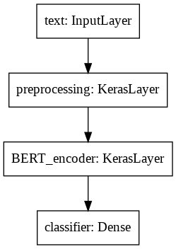

```python
classifier_model = build_model_comment()
tf.keras.utils.plot_model(classifier_model)
```

# simple base model for comment classification

Learning rate = 3e-5

```python
print(f'Training model with {tfhub_handle_encoder}')
print('Model with lr = 3e-5')
m_histories_comment_class['simple_electra_lr_3e-5'] = compile_fit_model(train_features=X_train, train_target=y_train, val_features=x_val, val_target=y_val,
                                                              model_name=classifier_model, name_callback = 'models/simple_electra_lr_3e-5',
                                                        loss_function='binary_crossentropy', max_epochs=10)
```

```
Training model with https://tfhub.dev/google/electra_base/2
Model with lr = 3e-5
```

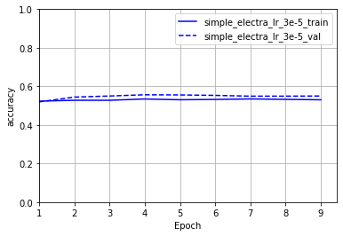

```python
plotter(m_histories_comment_class, ylim=[0.0, 1], metric = 'accuracy')
```

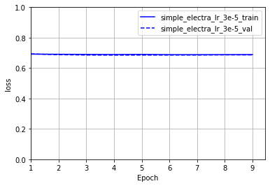

```python
plotter(m_histories_comment_class, metric = 'loss')
```

complex model

```python
def build_model_complex(activation_func):
  tweet_input = tf.keras.layers.Input(shape=(), dtype = tf.string, name='text')
  preprocessing_layer = hub.KerasLayer(tfhub_handle_preprocess, name='preprocessing')
  encoder_inputs = preprocessing_layer(tweet_input)
  encoder = hub.KerasLayer(tfhub_handle_encoder, trainable=False, name='BERT_encoder')
  outputs = encoder(encoder_inputs)

  model = outputs['pooled_output']
  model = tf.keras.layers.Dense(100, activation =activation_func)(model)
  model = tf.keras.layers.Dense(25, activation =activation_func)(model)
  model = tf.keras.layers.Dense(1, activation='sigmoid', name='classifier')(model)
  return tf.keras.Model(tweet_input, model)
```

```python
complex_model = build_model_complex()
print(f'Training model with {tfhub_handle_encoder}')
m_histories_comment_class['complex_electra_lr_3e-5'] = compile_fit_model(train_features=X_train, train_target=y_train, val_features=x_val, val_target=y_val,
                                                              model_name=complex_model, name_callback = 'models/complex_electra_lr_3e-5',
                                                        loss_function='binary_crossentropy', max_epochs=10)
```

```
Training model with https://tfhub.dev/google/electra_base/2
```

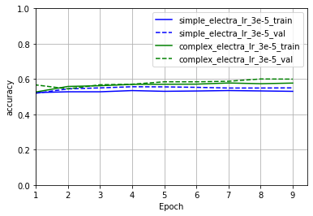

```python
plotter(m_histories_comment_class, ylim=[0.0, 1], metric = 'accuracy')
```

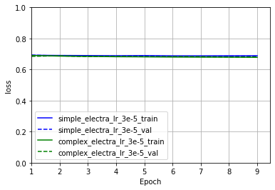

```python
plotter(m_histories_comment_class, ylim=[0.0, 1], metric = 'loss')
```

Analysis : The accuracy has increased by using complex model and the loss can be still decreased by using more epochs.

# Experiment with learning rate = 3e-05, 5e-05

```python
m_history_lr = {}
```

```python
complex_model_less_lr = build_model_complex()
print(f'Training model with {tfhub_handle_encoder}')
m_history_lr['complex_electra_lr_3e-5'] = compile_fit_model(train_features=X_train, train_target=y_train, val_features=x_val, val_target=y_val,
                                                              model_name=complex_model_less_lr, name_callback = 'models/complex_electra_lr_3e-5',
                                                        loss_function='binary_crossentropy', max_epochs=10)
```

```
Training model with https://tfhub.dev/google/electra_base/2
```

```python
complex_model_high_lr = build_model_complex()
m_history_lr['complex_electra_lr_5e-5'] = compile_fit_model(train_features=X_train, train_target=y_train, val_features=x_val, val_target=y_val,
                                                              model_name=complex_model_high_lr, name_callback = 'models/complex_electra_lr_5e-5',
                                                        loss_function='binary_crossentropy', max_epochs=10, lr=5e-5)
```

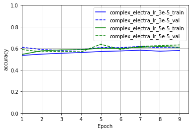

```python
plotter(m_history_lr, metric = 'accuracy')
```

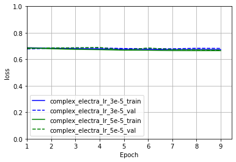

```python
plotter(m_history_lr, ylim=[0.0, 1], metric = 'loss')
```

Analysis of Learning Experiment: The accuracy for model with Learning rate = 5e-5 is better. The model with lr= 5e-5 will be used for further processing.

# Experiment with activation functions - relu, elu and tanh

```python
m_history_activation_func = {}
```

```python
complex_model_relu = build_model_complex()
print(f'Training model with {tfhub_handle_encoder}')
m_history_activation_func['complex_electra_relu'] = compile_fit_model(train_features=X_train, train_target=y_train, val_features=x_val, val_target=y_val,
                                                              model_name=complex_model_relu, name_callback = 'models/complex_electra_relu',
                                                        loss_function='binary_crossentropy', max_epochs=8,lr=5e-5)
```

```
Training model with https://tfhub.dev/google/electra_base/2
```

```python
complex_model_elu = build_model_complex(activation_func='elu')
print(f'Training model with {tfhub_handle_encoder}')
m_history_activation_func['complex_electra_elu'] = compile_fit_model(train_features=X_train, train_target=y_train, val_features=x_val, val_target=y_val,
                                                              model_name=complex_model_elu, name_callback = 'models/complex_electra_elu',
                                                        loss_function='binary_crossentropy', max_epochs=8,lr=5e-5)
```

```
Training model with https://tfhub.dev/google/electra_base/2
```

```python
complex_model_tanh = build_model_complex(activation_func='tanh')
print(f'Training model with {tfhub_handle_encoder}')
m_history_activation_func['complex_electra_tanh'] = compile_fit_model(train_features=X_train, train_target=y_train, val_features=x_val, val_target=y_val,
                                                              model_name=complex_model_tanh, name_callback = 'models/complex_electra_tanh',
                                                        loss_function='binary_crossentropy', max_epochs=8,lr=5e-5)
```

```
Training model with https://tfhub.dev/google/electra_base/2
```

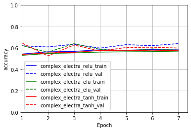

```python
plotter(m_history_activation_func, metric = 'accuracy')
```

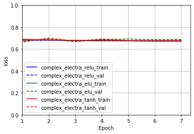

```python
plotter(m_history_activation_func, metric = 'loss')
```

Analysis : The training data is more due to the oversampling to resolve the class imbalance issue. So the training accuracy is a bit less compared to the validation accuracy. Comparing all the outputs of the model using different activation functions we can conclude that there is no drastic change in the accuracy. So I will continue using relu as the activation function

Building a more complex model to check if the accuracy can be further increased

```python
def build_model_complex_high_acc(activation_func):
  tweet_input = tf.keras.layers.Input(shape=(), dtype = tf.string, name='text')
  preprocessing_layer = hub.KerasLayer(tfhub_handle_preprocess, name='preprocessing')
  encoder_inputs = preprocessing_layer(tweet_input)
  encoder = hub.KerasLayer(tfhub_handle_encoder, trainable=False, name='BERT_encoder')
  outputs = encoder(encoder_inputs)

  model = outputs['pooled_output']
  model = tf.keras.layers.Dense(1000, activation =activation_func)(model)
  model = tf.keras.layers.Dense(500, activation =activation_func)(model)
  model = tf.keras.layers.Dense(50, activation =activation_func)(model)
  model = tf.keras.layers.Dense(1, activation='sigmoid', name='classifier')(model)
  return tf.keras.Model(tweet_input, model)
```

```python
m_history_more_complex = {}
```

```python
more_complex_model = build_model_complex_high_acc(activation_func='relu')
print(f'Training model with {tfhub_handle_encoder}')
m_history_more_complex['more_complex_electra'] = compile_fit_model(train_features=X_train, train_target=y_train, val_features=x_val, val_target=y_val,
                                                              model_name=more_complex_model, name_callback = 'models/more_complex_model',
                                                        loss_function='binary_crossentropy', max_epochs=8,lr=5e-5)
```

```
Training model with https://tfhub.dev/google/electra_base/2
```

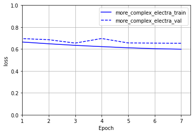

```python
plotter(m_history_more_complex, metric = 'loss')
```

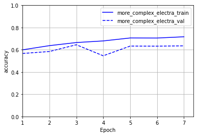

```python
plotter(m_history_more_complex, metric = 'accuracy')
```

There is some overfitting , so we can experiment with dropout and try to reduce the overfitting

```python
def build_model_complex_dropout(activation_func):
  tweet_input = tf.keras.layers.Input(shape=(), dtype = tf.string, name='text')
  preprocessing_layer = hub.KerasLayer(tfhub_handle_preprocess, name='preprocessing')
  encoder_inputs = preprocessing_layer(tweet_input)
  encoder = hub.KerasLayer(tfhub_handle_encoder, trainable=False, name='BERT_encoder')
  outputs = encoder(encoder_inputs)

  model = outputs['pooled_output']
  model = tf.keras.layers.Dropout(0.1)(model)
  model = tf.keras.layers.Dense(1000, activation =activation_func)(model)
  model = tf.keras.layers.Dense(500, activation =activation_func)(model)
  model = tf.keras.layers.Dense(50, activation =activation_func)(model)
  model = tf.keras.layers.Dropout(0.2)(model)
  model = tf.keras.layers.Dense(1, activation='sigmoid', name='classifier')(model)
  return tf.keras.Model(tweet_input, model)
```

```python
model_dropout = build_model_complex_dropout(activation_func='relu')
print(f'Training model with {tfhub_handle_encoder}')
m_history_more_complex['more_complex_electra_dropout'] = compile_fit_model(train_features=X_train, train_target=y_train, val_features=x_val, val_target=y_val,
                                                              model_name=model_dropout, name_callback = 'models/complex_model_dropout',
                                                        loss_function='binary_crossentropy', max_epochs=8,lr=5e-5)
```

```
Training model with https://tfhub.dev/google/electra_base/2
```

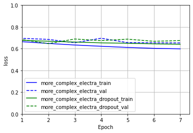

```python
plotter(m_history_more_complex, metric = 'loss')
```

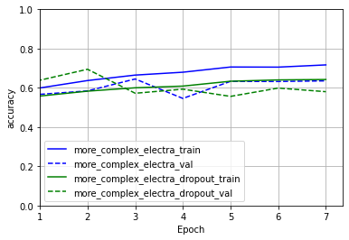

```python
plotter(m_history_more_complex, metric = 'accuracy')
```

Analysis: After adding the dropout the overfitting has decreased.

The model is completely fine tuned and now I can train the model for larger epoch value.

```python
history_final_model = {}
```

```python
final_model_comment_class = build_model_complex_dropout(activation_func='relu')
print(f'Training model with {tfhub_handle_encoder}')
history_final_model['final_model_comment'] = compile_fit_model(train_features=X_train, train_target=y_train, val_features=x_val, val_target=y_val,
                                                              model_name=final_model_comment_class, name_callback = 'models/final_model_comment',
                                                        loss_function='binary_crossentropy', max_epochs=60,lr=5e-5)
```

```
Training model with https://tfhub.dev/google/electra_base/2
```

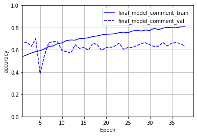

```python
plotter(history_final_model, metric = 'accuracy')
```

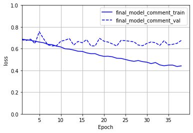

```python
plotter(history_final_model, metric = 'loss')
```

Analysis: From the above plots we can conclude that the comment classification model has good accuracy on the training and validation data. There is some amount of overfitting after 25 epochs. Even though the max_epochs = 60 the model training is stopped after 39 epochs as the Early stopping was triggered.

Evaluate the final comment classification model on the test set

```python
final_model_comment_class.evaluate(x_test,y_test)
```

```
[0.6701050996780396,
 0.6426858305931091,
 0.7591241002082825,
 0.7147766351699829]
```

```python
# extract the prediction values
y_predicted = final_model_comment_class.predict(x_test)
import numpy as np

y_predicted = y_predicted.flatten()
# considering the threshold as 0.5 for sigmoid
y_predicted = np.where(y_predicted > 0.5, 1, 0)
y_predicted
```

```
array([0, 1, 1, ..., 0, 1, 1])
```

```python
from sklearn.metrics import confusion_matrix, classification_report

cm = confusion_matrix(y_test, y_predicted)
cm
```

```
array([[180, 198],
       [249, 624]])
```

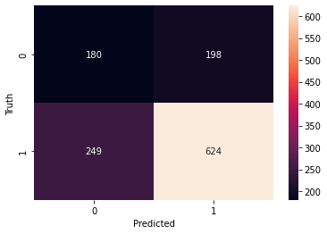

```python
from matplotlib import pyplot as plt
import seaborn as sn
sn.heatmap(cm, annot=True, fmt='d')
plt.xlabel('Predicted')
plt.ylabel('Truth')
```

```python
print(classification_report(y_test, y_predicted))
```

```
              precision    recall  f1-score   support

           0       0.42      0.48      0.45       378
           1       0.76      0.71      0.74       873

    accuracy                           0.64      1251
   macro avg       0.59      0.60      0.59      1251
weighted avg       0.66      0.64      0.65      1251
```

Analysis: The accuracy of the model is good but we can observe that the model performance is still less in case of predicting the non-comment class. Although the random oversampling of data was used , it just randomly picks the same data, so that model is not learning any new features. The other techniques like smote can be used to solve data imbalance but it would create ambiguous data.

# Classifying SDQ

```python
# using the preprocssed data for sdq classification
df_sdq_data.head(5)
```

|  | Text | Class |
| --- | --- | --- |
| 1 | u robin names andreas lubitz as the copilot in... | query |
| 2 | u robin names andreas lubitz as the copilot in... | comment |
| 4 | rt german media reporting andreaslubitz had a... | comment |
| 5 | rt german media reporting andreaslubitz had a... | comment |
| 6 | rt german media reporting andreaslubitz had a... | comment |

```python
# exclude all the rows with Class = Comment
df_sdq_exclude_comment = df_sdq_data[df_sdq_data['Class']!='comment']
df_sdq_exclude_comment.Class.value_counts()
```

```
support    792
query      520
deny       496
Name: Class, dtype: int64
```

```python
# label encoding
from sklearn.preprocessing import LabelEncoder
l1 = LabelEncoder()

# encode the labels Class
df_sdq_encode = df_sdq_exclude_comment.copy()
df_sdq_encode['Class'] = l1.fit_transform(df_sdq_encode['Class'])

# check to make sure the target variable is encoded
df_sdq_encode.Class.value_counts()
```

```
2    792
1    520
0    496
Name: Class, dtype: int64
```

Visualistion of the sdq dataset

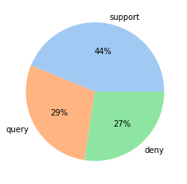

```python
labels = ['support','query','deny']
data = df_sdq_encode.Class.value_counts()

colors = sns.color_palette('pastel')[0:3]

#create pie chart
plt.pie(data, labels = labels, colors = colors, autopct='%.0f%%')
plt.show()
```

The SDQ data has slight imbalance. But it does not have any drastic imbalance like the comment classification data.

one hot encode the target variable Class

```python
target = np.array(df_sdq_encode['Class'].values.tolist())

# one hot encode the target variable - the shape will be [,3]
from tensorflow.keras.utils import to_categorical
target = to_categorical(target, dtype ="uint8")
```

```python
# check to make sure the target variable is one hot encoded
target[:10]
```

```
array([[0, 1, 0],
       [0, 1, 0],
       [1, 0, 0],
       [1, 0, 0],
       [0, 1, 0],
       [0, 1, 0],
       [0, 1, 0],
       [0, 0, 1],
       [0, 1, 0],
       [0, 1, 0]], dtype=uint8)
```

```python
df_sdq_encode.head(10)
```

|  | Text | Class |
| --- | --- | --- |
| 1 | u robin names andreas lubitz as the copilot in... | 1 |
| 9 | rt german media reporting andreaslubitz had a... | 1 |
| 13 | rt german media reporting andreaslubitz had a... | 0 |
| 17 | flight u initially climbed to feet before bef... | 0 |
| 22 | flight u initially climbed to feet before bef... | 1 |
| 24 | flight u initially climbed to feet before bef... | 1 |
| 28 | flight u initially climbed to feet before bef... | 1 |
| 38 | flight u initially climbed to feet before bef... | 2 |
| 51 | flight u initially climbed to feet before bef... | 1 |
| 55 | flight u initially climbed to feet before bef... | 1 |

Split the dataset into train , validation and test set

```python
# split the dataset into train, validation and test set
from sklearn.model_selection import train_test_split

# split the dataset into train dataset(60%) and remainder dataset(40%)
X_train_sdq, X_rem_sdq, y_train_sdq, y_rem_sdq = train_test_split(df_sdq_encode['Text'],target,train_size=0.7, shuffle=True,stratify=target, random_state=999)

# split the remaining 40% data between validation and test set
x_val_sdq, x_test_sdq, y_val_sdq, y_test_sdq = train_test_split(X_rem_sdq, y_rem_sdq ,test_size=0.5, shuffle=True, random_state=999)
```

```python
print('shape of train data :',X_train_sdq.shape)
print('shape of validation data :',x_val_sdq.shape)
print('shape of test data :',x_test_sdq.shape)
```

```
shape of train data : (1265,)
shape of validation data : (271,)
shape of test data : (272,)
```

Base model

```python
def build_model_simple_classifySDQ():
  tweet_input = tf.keras.layers.Input(shape=(), dtype = tf.string, name='text')
  preprocessing_layer = hub.KerasLayer(tfhub_handle_preprocess, name='preprocessing')
  encoder_inputs = preprocessing_layer(tweet_input)
  encoder = hub.KerasLayer(tfhub_handle_encoder, trainable=False, name='BERT_encoder')
  outputs = encoder(encoder_inputs)

  net = outputs['pooled_output']
  net = tf.keras.layers.Dense(3, activation='softmax', name='classifier')(net)
  return tf.keras.Model(tweet_input, net)
```

```python
model_electra_sdq = build_model_simple_classifySDQ()
model_electra_sdq.summary()
```

[output not shown]

```python
m_histories_sdq_class = {}
```

```python
TRAIN_DATA_LEN = X_train_sdq.shape[0]
BATCH_SIZE = 64

print(f'Training model with {tfhub_handle_encoder}')
m_histories_sdq_class['bert_electra_sdq'] = compile_fit_model(train_features=X_train_sdq, train_target=y_train_sdq, val_features=x_val_sdq, val_target=y_val_sdq,
                                                              model_name=model_electra_sdq, name_callback = 'models/bert_electra_sdq', max_epochs=8)
```

```
Training model with https://tfhub.dev/google/electra_base/2
```

Build a Complex Sdq model

```python
def build_model_complex_classifySDQ(activation_func):
  tweet_input = tf.keras.layers.Input(shape=(), dtype = tf.string, name='text')
  preprocessing_layer = hub.KerasLayer(tfhub_handle_preprocess, name='preprocessing')
  encoder_inputs = preprocessing_layer(tweet_input)
  encoder = hub.KerasLayer(tfhub_handle_encoder, trainable=False, name='BERT_encoder')
  outputs = encoder(encoder_inputs)

  net = outputs['pooled_output']
  #net = tf.keras.layers.Dropout(0.1)(net)
  net = tf.keras.layers.Dense(1000, activation=activation_func)(net)
  net = tf.keras.layers.Dense(500, activation=activation_func)(net)
  net = tf.keras.layers.Dense(25, activation=activation_func)(net)
  #net = tf.keras.layers.Dropout(0.2)(net)
  net = tf.keras.layers.Dense(3, activation='softmax', name='classifier')(net)
  return tf.keras.Model(tweet_input, net)
```

```python
complex_model_sdq = build_model_complex_classifySDQ()
print(f'Training model with {tfhub_handle_encoder}')
m_histories_sdq_class['electra_complex_model'] = compile_fit_model(train_features=X_train_sdq, train_target=y_train_sdq, val_features=x_val_sdq, val_target=y_val_sdq,
                                                              model_name=complex_model_sdq, name_callback = 'models/electra_complex_sdq', max_epochs=8)
```

```
Training model with https://tfhub.dev/google/electra_base/2
```

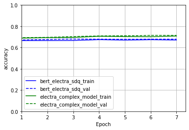

```python
plotter(m_histories_sdq_class,metric = 'accuracy')
```

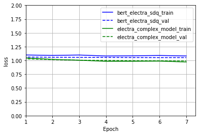

```python
plotter(m_histories_sdq_class,ylim=[0,2], metric = 'loss')
```

Analysis : There is less overfitting in the model and accuracy is a bit higher in the complex model and also the loss (categorical cross entropy) is less in the complex model.

# Experiment with Learning rate using the complex model

```python
m_history_lr = {}
```

```python
complex_model_sdq_less_lr = build_model_complex_classifySDQ()
m_history_lr['complex_electra_lr_3e-5'] = compile_fit_model(train_features=X_train_sdq, train_target=y_train_sdq, val_features=x_val_sdq, val_target=y_val_sdq,
                                                              model_name=complex_model_sdq_less_lr, name_callback = 'models/complex_electra_lr_3e-5',
                                                              max_epochs=10)
```

```python
complex_model_sdq_high_lr = build_model_complex_classifySDQ()
m_history_lr['complex_electra_lr_5e-5'] = compile_fit_model(train_features=X_train_sdq, train_target=y_train_sdq, val_features=x_val_sdq, val_target=y_val_sdq,
                                                              model_name=complex_model_sdq_high_lr, name_callback = 'models/complex_electra_lr_5e-5',
                                                              max_epochs=10)
```

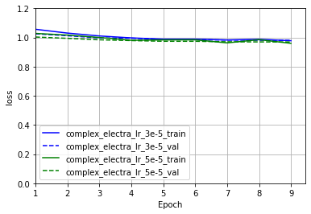

```python
plotter(m_history_lr,ylim=[0,1.2], metric = 'loss')
```

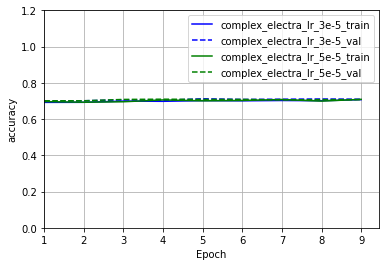

```python
plotter(m_history_lr,ylim=[0,1.2], metric = 'accuracy')
```

# Experiment with activation functions

```python
m_history_activation_sdq = {}
```

```python
# using relu as activation function
complex_model_sdq_relu = build_model_complex_classifySDQ()
m_history_activation_sdq['complex_electra_relu'] = compile_fit_model(train_features=X_train_sdq, train_target=y_train_sdq, val_features=x_val_sdq, val_target=y_val_sdq,
                                                              model_name=complex_model_sdq_relu, name_callback = 'models/complex_electra_relu',
                                                              max_epochs=10)
```

```python
# using elu as activation function
complex_model_sdq_elu = build_model_complex_classifySDQ(activation_func = 'elu')
m_history_activation_sdq['complex_electra_elu'] = compile_fit_model(train_features=X_train_sdq, train_target=y_train_sdq, val_features=x_val_sdq, val_target=y_val_sdq,
                                                              model_name=complex_model_sdq_elu, name_callback = 'models/complex_electra_elu',
                                                              max_epochs=10)
```

```python
# using tanh as activation function
complex_model_sdq_tanh = build_model_complex_classifySDQ(activation_func = 'tanh')
m_history_activation_sdq['complex_electra_tanh'] = compile_fit_model(train_features=X_train_sdq, train_target=y_train_sdq, val_features=x_val_sdq, val_target=y_val_sdq,
                                                              model_name=complex_model_sdq_tanh, name_callback = 'models/complex_electra_tanh',
                                                              max_epochs=10)
```

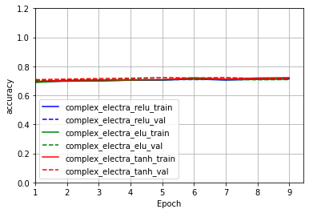

```python
plotter(m_history_activation_sdq,ylim=[0,1.2], metric = 'accuracy')
```

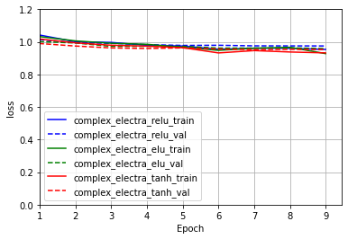

```python
plotter(m_history_activation_sdq,ylim=[0,1.2], metric = 'loss')
```

Final model SDQ classification

```python
m_histories_final_model_sdq = {}
```

```python
# using tanh as activation function
final_model_sdq = build_model_complex_classifySDQ(activation_func = 'relu')
m_histories_final_model_sdq['final_model_sdq'] = compile_fit_model(train_features=X_train_sdq, train_target=y_train_sdq, val_features=x_val_sdq, val_target=y_val_sdq,
                                                              model_name=final_model_sdq, name_callback = 'models/final_model_sdq',
                                                              max_epochs=60)
```

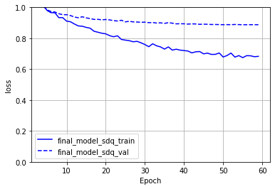

```python
plotter(m_histories_final_model_sdq, metric = 'loss')
```

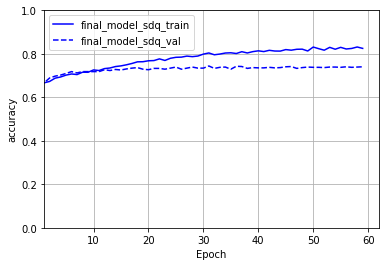

```python
plotter(m_histories_final_model_sdq, metric = 'accuracy')
```

# Evaluate the fine tuned model sdq on the test data

```python
final_model_sdq.evaluate(x_test_sdq,y_test_sdq)
```

```
[0.9826081395149231,
 0.7132352590560913,
 0.6266666650772095,
 0.34558823704719543]
```

```python
y_predicted = final_model_sdq.predict(x_test_sdq)
```

```python
y_test_sdq[0]
```

```
array([0, 0, 1], dtype=uint8)
```

```python
np.argmax(y_test_sdq[0])
```

```
2
```

```python
predict_li = []
expected_li = []
for i in range(y_predicted.shape[0]):
  predict_li.append(np.argmax(y_predicted[i]))
  expected_li.append(np.argmax(y_test_sdq[i]))
```

```python
from sklearn.metrics import confusion_matrix, classification_report
cm = confusion_matrix(expected_li , predict_li)
cm
```

```
array([[26, 25, 28],
       [11, 44, 25],
       [15, 22, 76]])
```

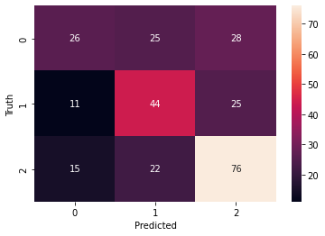

```python
from matplotlib import pyplot as plt
import seaborn as sn
sn.heatmap(cm, annot=True, fmt='d')
plt.xlabel('Predicted')
plt.ylabel('Truth')

# deny = 0, query = 1, support = 2
```

Analysis: From the above confusion matrix we can conclude that model is not good in classifying the traget value deny as it has less observations(tweets) with Class = deny.

# testing on reddit data

```python
df_test_reddit =  pd.read_csv('/content/Rumour_data/Extra_reddit_dataset.csv')
df_test_reddit.head(5)
```

|  | Type | Msg_ID | Source_Msg_ID | Text | Topic | Class |
| --- | --- | --- | --- | --- | --- | --- |
| 0 | Source | 63uefi | -1 | Donald Trump's travel expenses in 10 weeks cos... | None | -1 |
| 1 | Reply | dfx7l1a | 63uefi | But he was from 2001-2009? I don't get what di... | None | comment |
| 2 | Reply | dfx88qg | 63uefi | Cheney resigned as CEO of Halliburton on July ... | None | comment |
| 3 | Reply | dfx3i17 | 63uefi | [deleted] | None | comment |
| 4 | Reply | dfx4yef | 63uefi | That is literally not a source, that is Niamh ... | None | comment |

```python
df_test_reddit.shape
```

```
(2471, 6)
```

Adding the seperator '|' between the source and the response tweet

```python
# seperate the source records in a new dataframe
df_source_reddit = df_test_reddit[df_test_reddit['Type']=='Source']

# create a dictionary of msg_id as the key and the source tweet text as the value
source_dict_reddit = {}

# dictionary key = Msg_id and the value will be tweet text
for i in range(df_source_reddit.shape[0]):

  source_dict_reddit[df_source_reddit.iloc[i, df_source_reddit.columns.get_loc("Msg_ID")]] = df_source_reddit.iloc[i, df_source_reddit.columns.get_loc("Text")]
```

```python
print(source_dict_reddit.get('63uefi'))
```

```
Donald Trump's travel expenses in 10 weeks cost US taxpayers as much as Barack Obama spent in two years
```

```python
# exclude all the rows with source msg
df_exclude_source_reddit = df_test_reddit[df_test_reddit['Class']!='-1']

for i in range(df_exclude_source_reddit.shape[0]):
  msg_id = df_exclude_source_reddit.iloc[i, df_exclude_source_reddit.columns.get_loc("Source_Msg_ID")]

  # access the source text using the msg id from the source dictionary
  pair_tweet = source_dict_reddit.get(msg_id) + ' | ' + df_exclude_source_reddit.iloc[i, df_exclude_source_reddit.columns.get_loc("Text")]

  # conactenate the source tweet and reply using | as a seperator

  df_exclude_source_reddit.iloc[i, df_exclude_source_reddit.columns.get_loc("Text")] = pair_tweet
```

```python
df_exclude_source_reddit.Text.iloc[0]
```

```
"Donald Trump's travel expenses in 10 weeks cost US taxpayers as much as Barack Obama spent in two years | But he was from 2001-2009? I don't get what distinction you are making."
```

```python
# select the Text and Class(Target) attributes and add it to a new dataset
df_preprocess_reddit = df_exclude_source_reddit[['Text', 'Class']]
df_preprocess_reddit.head(5)
```

|  | Text | Class |
| --- | --- | --- |
| 1 | Donald Trump's travel expenses in 10 weeks cos... | comment |
| 2 | Donald Trump's travel expenses in 10 weeks cos... | comment |
| 3 | Donald Trump's travel expenses in 10 weeks cos... | comment |
| 4 | Donald Trump's travel expenses in 10 weeks cos... | comment |
| 5 | Donald Trump's travel expenses in 10 weeks cos... | comment |

Pre-process the reddit dataset

```python
def preprocess_data(df_data_preprocess):


	# Preprocess the textf

	import re

	# regular expression to remove url
	url = r"(https?:\/\/(?:www\.|(?!www))[a-zA-Z0-9][a-zA-Z0-9-]+[a-zA-Z0-9]\.[^\s]{2,}|www\.[a-zA-Z0-9][a-zA-Z0-9-]+[a-zA-Z0-9]\.[^\s]{2,}|https?:\/\/(?:www\.|(?!www))[a-zA-Z0-9]+\.[^\s]{2,}|www\.[a-zA-Z0-9]+\.[^\s]{2,})"

	for i in range(df_data_preprocess.shape[0]):
		# remove url
		preprocess_text = re.sub(url, "", df_data_preprocess['Text'].iloc[i])
		# remove @ and followed by the word
		preprocess_text = re.sub(r"@\w+", "", preprocess_text)
		df_data_preprocess['Text'].iloc[i] = preprocess_text


	# convert all the text to lower case
	df_data_preprocess["Text"] = df_data_preprocess["Text"].str.lower()
	df_data_preprocess['Class'] =  df_data_preprocess['Class'].str.lower()

	# remove all punctuations except |
	df_data_preprocess["Text"] = df_data_preprocess['Text'].str.replace(r'[^\w\s|]', '')


	# strip whitespaces
	df_data_preprocess['Text'] = df_data_preprocess['Text'].str.strip()
	df_data_preprocess['Class'] = df_data_preprocess['Class'].str.strip()

	# remove all alphanumeric characters
	df_data_preprocess['Text']= df_data_preprocess['Text'].str.replace('[^a-zA-Z|\s]', '')

	return df_data_preprocess
```

```python
clean_data = preprocess_data(df_preprocess_reddit)
```

```python
# create a copy for comment classification
df_reddit_comment = clean_data.copy()

# create a copy for the sdq classification
df_reddit_sdq = clean_data.copy()
```

comment classification model

```python
# find the prediction comment and non-comment for reddit data using the final_model_comment_class
y_predicted = final_model_comment_class.predict(clean_data.Text)
y_predicted = y_predicted.flatten()
```

```python
len(y_predicted)
```

```
2431
```

```python
# using the probability threshold as 0.5 classify the tweets as commen=1 (if prob>0.5) and non-comment = 0(if prob<=0.5)
y_predicted_li = np.where(y_predicted > 0.5, 1, 0)
y_predicted_li
```

```
array([1, 1, 1, ..., 1, 1, 1])
```

SDQ classification model

```python
# find all the predictions on the reddit data
y_predicted_reddit = final_model_sdq.predict(clean_data.Text)
```

```python
y_predicted_reddit[0]
```

```
array([0.3043782 , 0.3646685 , 0.33095327], dtype=float32)
```

Since softmax is used the output will max likelihood prob for each of the class. Find the max likelihood using the np.argmax and append it to list. So the list will contain values like (0,1,2,1,2,1). Where 0 = deny, 1 = query and support = 2.

```python
predict_li = []
for i in range(y_predicted_reddit.shape[0]):
  predict_li.append(np.argmax(y_predicted_reddit[i]))
```

```python
len(y_predicted_reddit)
```

```
2431
```

```python
# add the prediction data from both the models to a list
final_predictions = []
for index,i in enumerate(y_predicted_li):

  # if the predicted value belongs to comment class value == 1 then just append it to the list
  if i == 1:
    final_predictions.append(i)

  # else the value == 0 , then find the value of non-comment class for that particular index in predict_li
  # if predict_li has value 0 which corresponds to deny then add 2 to the value and append it as 2.
  # if predict_li has value 1 which corresponds to query then add 2 to the value and append it as 3.
  # if predict_li has value 2 which corresponds to support then add 2 to the value and append it as 4.
  else:
    category_encode = predict_li[index] + 2
    final_predictions.append(category_encode)

# conclusion: The final_preditcions list will contain the values as 1- comment, 2- deny, 3-query and 4 - support.
```

```python
len(final_predictions)
```

```
2431
```

```python
final_data = clean_data.copy()
```

```python
# encode the target variables in the reddit to correspond to the values with the final_predictions list
# 1- comment, deny = 2, query = 3, support = 4
encode = {
    "comment" : 1,
    "deny"  : 2,
    "query" : 3,
    "support" : 4,
    }

final_data["Class"] = final_data["Class"].apply(lambda x: encode[x])
final_data.head(5)
```

|  | Text | Class |
| --- | --- | --- |
| 1 | donald trumps travel expenses in weeks cost u... | 1 |
| 2 | donald trumps travel expenses in weeks cost u... | 1 |
| 3 | donald trumps travel expenses in weeks cost u... | 1 |
| 4 | donald trumps travel expenses in weeks cost u... | 1 |
| 5 | donald trumps travel expenses in weeks cost u... | 1 |

```python
final_data.Class.value_counts()
```

```
1    2250
2      94
3      64
4      23
Name: Class, dtype: int64
```

```python
from sklearn.metrics import confusion_matrix, classification_report

cm = confusion_matrix(final_data.Class,final_predictions )
cm
```

```
array([[1752,  187,  182,  129],
       [  64,   10,   17,    3],
       [  39,    5,   11,    9],
       [  12,    5,    2,    4]])
```

[output not shown]

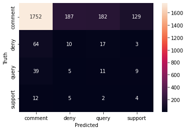

```python
from matplotlib import pyplot as plt
import seaborn as sn
a = sn.heatmap(cm, annot=True, fmt='d')
plt.xlabel('Predicted')
plt.ylabel('Truth')
#ax.xaxis.set_ticklabels(['business', 'health'])
a.set_xticklabels(['comment','deny','query','support'])
a.set_yticklabels(['comment','deny','query','support'])
```

```python
print(classification_report(final_data.Class,final_predictions ))
```

```
              precision    recall  f1-score   support

           1       0.94      0.78      0.85      2250
           2       0.05      0.11      0.07        94
           3       0.05      0.17      0.08        64
           4       0.03      0.17      0.05        23

    accuracy                           0.73      2431
   macro avg       0.27      0.31      0.26      2431
weighted avg       0.87      0.73      0.79      2431
```

Analysis : From the above results we can conclude that model is good at classifying comment but the performance of the model is poor in classifying SDQ. Since the Reddit data is imbalanced we can use F1-score as the performance metric to analyse the model. The poor performance in the SDQ classification is due to the less data corresponding to the class SDQ(Support, Deny, Query).